# Lab 5

# 2

```python
df["age_2"] = df["age"] ** 2
x = df[["age", "age_2"]]
y = df["charges"]
x_train, x_test, y_train, y_test = train_test_split(x, y, test_size=0.2, random_state=0)
model = LinearRegression()
model.fit(x_train, y_train)
y_pred = model.predict(x_test)
mse = mean_squared_error(y_test, y_pred)
r2  = r2_score(y_test, y_pred)
coef = model.coef_[0]
coef1 = model.coef_[1]
intercept = model.intercept_
print("age =",coef)
print("age^2 =",coef1)
print("intercept =",intercept)
print("r2 =",r2)
print("mse =",mse)
```

```
age = 249.28835614913473
age^2 = -0.5048241148195072
intercept = 3930.9087767435994
r2 = 0.16900622657826136
mse = 107413429.44815743
```

# The MSE is lower and the R2 is higher in this model compared to part 2 question 1.

# 3

```python
x = df[["age"]]
y = df["charges"]
poly = PolynomialFeatures(degree=4, include_bias=False)
x_4 = poly.fit_transform(x)
x_train, x_test, y_train, y_test = train_test_split(x_4, y, test_size=0.2, random_state=0)
model = LinearRegression()
model.fit(x_train, y_train)
y_pred = model.predict(x_test)
mse = mean_squared_error(y_test, y_pred)
r2  = r2_score(y_test, y_pred)
coef = model.coef_[3]
intercept = model.intercept_
print("age^4 =",coef)
print("intercept =",intercept)
print("r2 =",r2)
print("mse =",mse)
```

```
age^4 = 0.049883210022380275
intercept = 87363.39892906052
r2 = 0.16148584279609002
mse = 108385506.78332584
```

# The MSE is higher and the R2 is lower in this model compared to part 2 question 1.

# 5. According to the MSE and R-squared, which is the best model? Do you agree that this is indeed the “best” model? Why or why not?

# The best model was the model from question 1. I agree that it is the best model out of the group because it’s using two relevant variables and isn’t a polynomial.

# 4

```
age^12 = -7.607051418256245e-17
intercept = 8601.959483987806
r2 = 0.14699432117444922
mse = 110258666.46885885
```

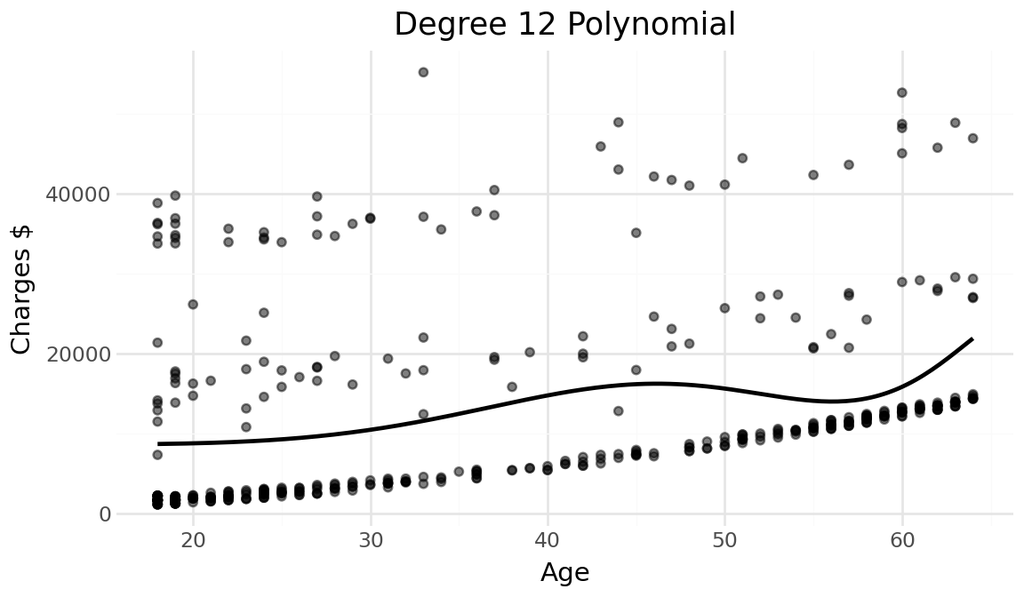

```python
x = df[["age"]]
y = df["charges"]
poly = PolynomialFeatures(degree=12, include_bias=False)
x_12 = poly.fit_transform(x)
x_train, x_test, y_train, y_test = train_test_split(x_12, y, test_size=0.2, random_state=0)
model = LinearRegression()
model.fit(x_train, y_train)
y_pred = model.predict(x_test)
mse = mean_squared_error(y_test, y_pred)
r2  = r2_score(y_test, y_pred)
coef = model.coef_[11]
intercept = model.intercept_
print("age^12 =",coef)
print("intercept =",intercept)
print("r2 =",r2)
print("mse =",mse)

age_grid = np.linspace(df["age"].min(), df["age"].max(), 200).reshape(-1, 1)
age_12 = poly.transform(age_grid)
y_fit = model.predict(age_12)
plot_df = pd.DataFrame({"age": age_grid.flatten(), "fitted": y_fit})
(
ggplot(df, aes(x="age", y="charges"))
    + geom_point(alpha=0.5)
    + geom_line(plot_df, aes(x="age", y="fitted"), size=1)
    + labs(title="Degree 12 Polynomial",
           x="Age", y="Charges $")
    + theme_minimal()
    )
```

# The MSE is higher and the R2 is lower in this model compared to part 2 question 1.

# 4 New Data

# 1

```python
df_new = pd.read_csv("insurance_costs_2.csv")
df_new = pd.get_dummies(df_new, columns=["sex", "smoker"], drop_first=True)
x = df[["age"]]
y = df["charges"]
x_train, x_test, y_train, y_test = train_test_split(x, y)
model = LinearRegression()
model.fit(x_train, y_train)
x_new = df_new[["age"]]
y_pred = model.predict(x_new)
mse = mean_squared_error(df_new["charges"], y_pred)
r2 = r2_score(df_new["charges"], y_pred)
print("r2 =",r2)
print("mse =",mse)
```

```
r2 = 0.12473850213844884
mse = 135709149.6949694
```

# 2

```python
x = df[["age", "bmi"]]
y = df["charges"]
x_train, x_test, y_train, y_test = train_test_split(x, y)
model = LinearRegression()
model.fit(x_train, y_train)
x_new = df_new[["age", "bmi"]]
y_pred = model.predict(x_new)
mse = mean_squared_error(df_new["charges"], y_pred)
r2 = r2_score(df_new["charges"], y_pred)
print("r2 =",r2)
print("mse =",mse)
```

```
r2 = 0.147435268743635
mse = 132190019.80711247
```

# 3

```python
x = df[["age", "bmi", "smoker_yes"]]
y = df["charges"]
x_train, x_test, y_train, y_test = train_test_split(x, y)
model = LinearRegression()
model.fit(x_train, y_train)
x_new = df_new[["age", "bmi","smoker_yes"]]
y_pred = model.predict(x_new)
mse = mean_squared_error(df_new["charges"], y_pred)
r2 = r2_score(df_new["charges"], y_pred)
print("r2 =",r2)
print("mse =",mse)
```

```
r2 = 0.772596682773903
mse = 35258846.520689234
```

# 4

```python
df["age_smoker"] = df["age"] * df["smoker_yes"]
df["bmi_smoker"] = df["bmi"] * df["smoker_yes"]
df_new["age_smoker"] = df_new["age"] * df_new["smoker_yes"]
df_new["bmi_smoker"] = df_new["bmi"] * df_new["smoker_yes"]

x = df[["age_smoker", "bmi_smoker"]]
y = df["charges"]
x_train, x_test, y_train, y_test = train_test_split(x, y)
model = LinearRegression()
model.fit(x_train, y_train)
x_new = df_new[["age_smoker", "bmi_smoker"]]
y_pred = model.predict(x_new)
mse = mean_squared_error(df_new["charges"], y_pred)
r2 = r2_score(df_new["charges"], y_pred)
print("r2 =",r2)
print("mse =",mse)
```

```
r2 = 0.6915322562391963
mse = 47827872.374578126
```

# 5

```python
x = df[["age", "bmi", "smoker_yes", "age_smoker", "bmi_smoker"]]
y = df["charges"]
x_train, x_test, y_train, y_test = train_test_split(x, y)
model = LinearRegression()
model.fit(x_train, y_train)
x_new = df_new[["age", "bmi", "smoker_yes","age_smoker", "bmi_smoker"]]
y_pred = model.predict(x_new)
mse = mean_squared_error(df_new["charges"], y_pred)
r2 = r2_score(df_new["charges"], y_pred)
print("r2 =",r2)
print("mse =",mse)
```

```
r2 = 0.8591817959009477
mse = 21833839.128701072
```

# 6(Based on the R2 and mse the best model is the one with Age, BMI, and Smoker with interaction)

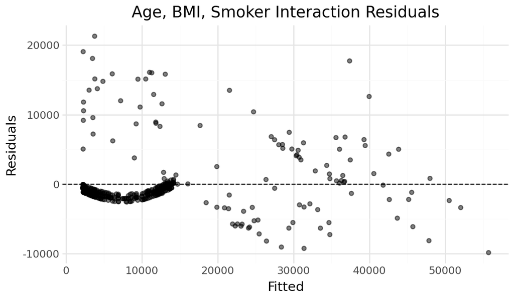

```python
x = df[["age", "bmi", "smoker_yes", "age_smoker", "bmi_smoker"]]
y = df["charges"]
model = LinearRegression()
model.fit(x, y)
y_hat = model.predict(x)
resid = y - y_hat
plot_df = pd.DataFrame({"fitted": y_hat, "resid": resid,"smoker_yes": x["smoker_yes"]})
(
ggplot(plot_df, aes(x="fitted", y="resid"))
+ geom_point(alpha=0.5)
+ geom_hline(yintercept=0, linetype="dashed")
+ labs(title="Age, BMI, Smoker Interaction Residuals", x="Fitted", y="Residuals")
+ theme_minimal()
)
```

# Part Five: Full Exploration

```
r2 = 0.8529119064254725
mse = 22805984.449244756
```

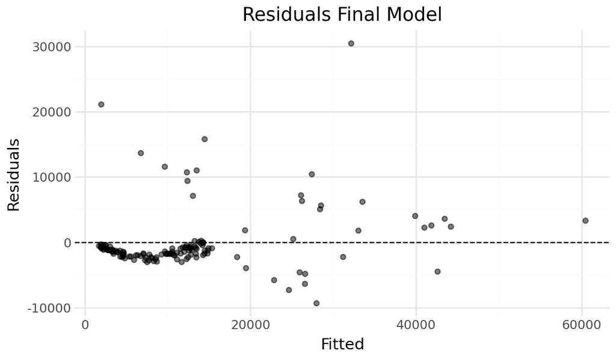

```python
df = pd.get_dummies(df, columns=["region"], drop_first=True)
df_new = pd.get_dummies(df_new, columns=["region"], drop_first=True)

x = df[["age", "bmi", "smoker_yes", "age_smoker", "bmi_smoker", "region_northwest", "region_southeast", "region_southwest"]]
y = df["charges"]
x_train, x_test, y_train, y_test = train_test_split(x, y)
model = LinearRegression()
model.fit(x_train, y_train)
x_new = df_new[["age", "bmi", "smoker_yes", "age_smoker", "bmi_smoker", "region_northwest", "region_southeast", "region_southwest"]]
y_pred = model.predict(x_new)
mse = mean_squared_error(df_new["charges"], y_pred)
r2 = r2_score(df_new["charges"], y_pred)
print("r2 =",r2)
print("mse =",mse)


resid = df_new["charges"] - y_pred
plot_df = pd.DataFrame({"fitted": y_pred, "resid": resid})

(ggplot(plot_df, aes(x="fitted", y="resid"))
    + geom_point(alpha=0.5)
    + geom_hline(yintercept=0, linetype="dashed")
    + labs(
        title="Residuals Final Model",
        x="Fitted",
        y="Residuals"
    )
    + theme_minimal()
)
```